# M6 - Diagnostik Model

Rafli Radithya

15/10/2023

## Tentang Data

Data yang digunakan merupakan data pertemuan 1 yaitu m4 data competition. Adapun data yang diambil pada peubah V2 sebanyak 150 data

## Input Data

```r
#Akses data
setwd("C:/Users/USER/OneDrive/Dokumen/PRAKTIKUM MPDW 2023/PRAKTIKUM MPDW 2023/pertemuan2/data")
mpdw=read.csv("mpdw2v2.csv",sep=";")
mpdw6=as.data.frame(mpdw)

#Diambil 150 data
mpdw6=mpdw6[1:150,]
mpdw6=as.data.frame(mpdw6)
mpdw6
```

```
##            V2        V3        V4        V5
## 1    2039.200  2035.000  2051.800  2061.800
## 2    2986.000  3001.200  2975.900  2996.100
## 3    1120.700  1117.900  1115.100  1112.300
## 4    1190.000  1162.000  1134.000  1106.000
## 5    5904.670  5917.050  5922.580  5928.800
## 6    3182.052  3147.099  3143.850  3128.200
## 7    5860.008  7773.246  9477.872  8209.099
## 8    1732.200  1731.830  1739.170  1741.800
## 9    1584.410  1584.060  1590.770  1592.650
## 10   2618.000  2638.600  2648.700  2656.200
## 11   2440.200  2439.700  2469.300  2434.400
## 12   3663.300  3670.600  3704.100  3695.200
## 13   7208.400  7262.700  7251.200  7320.400
## 14   5762.900  5721.800  5789.500  5756.000
```

[output cut: 136 more lines]

## Package

```r
library(ggplot2)
library(tsibble)
library(tseries)
library(MASS)
library(forecast)
library(TSA)
library(TTR)
library(aTSA)
library(graphics)
```

## Eksplorasi Data Latih + Uji

Sebelumnya, akan dilakukan pembagian 80% data training dan 20% data testing dari 150 data yang ada

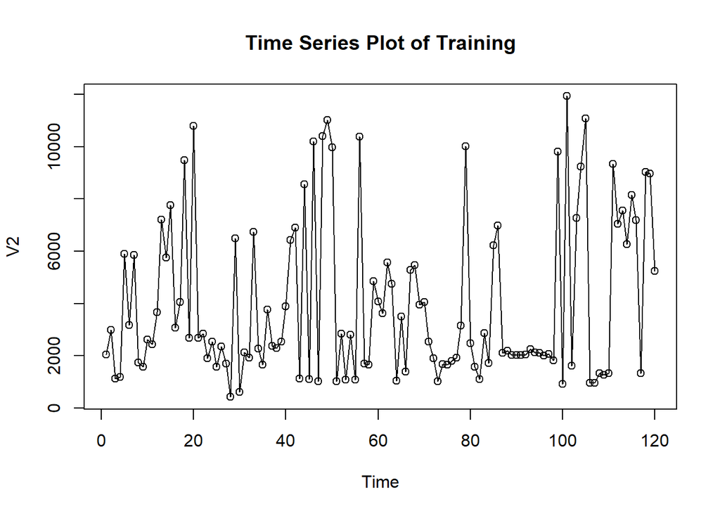

```r
#Training
mpdw.train = mpdw6[1:round(150*0.8),]
mpdw.train = ts(mpdw.train$V2)

#Testing
mpdw.test = mpdw6[1+round(150*0.8):150,]
mpdw.test = ts(mpdw.test$V2)

#Eksplorasi
par(mfrow=c(1,1))
#Data Training
ts.plot(mpdw.train, xlab="Time", ylab="V2", main= "Time Series Plot of Training")
points(mpdw.train)
```

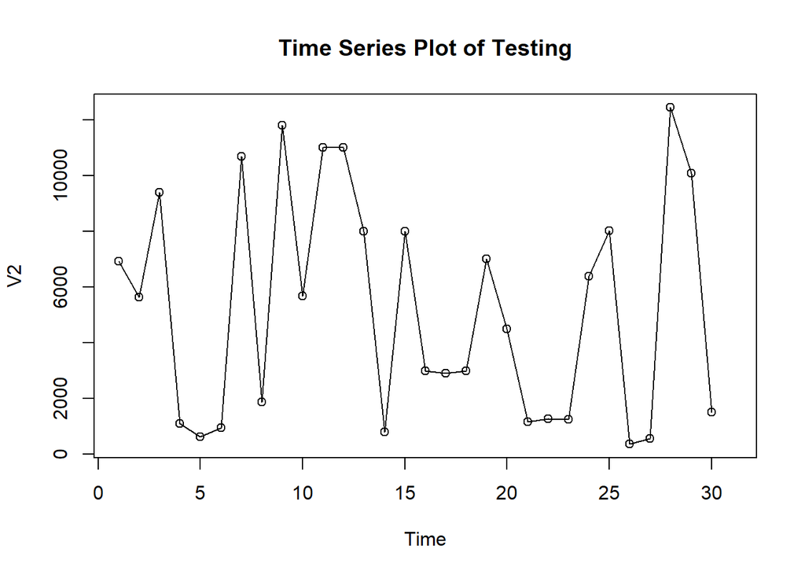

```r
#Data Testing
ts.plot(mpdw.test, xlab="Time", ylab="V2", main= "Time Series Plot of Testing")
points(mpdw.test)
```

Data training dan testing cenderung membentuk pola time series yang mirip, yaitu stasioner dalam rataan, tetapi tidak dalam ragam sehingga data tidak overfitting.

## Uji Stasioneritas Data

Dilakukan eksplorasi data dengan plot ACF untuk melihat pola lag pada data

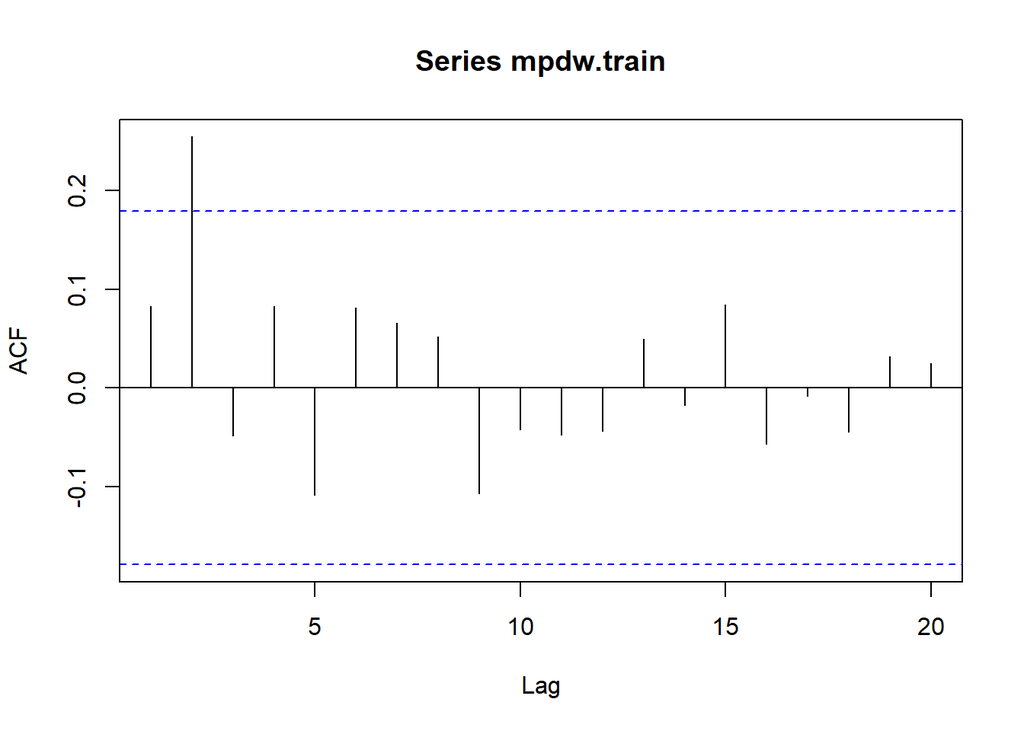

```r
#Plot ACF
acf(mpdw.train,lag.max = 20)
```

Berdasarkan plot ACF, terjadi cut-off pada lag 2 sehingga diduga data stasioner dalam rataan. Selanjutnya, akan dilakukan uji formalnya dengan uji ADF dengan hipotesis sebagai berikut

$H_0$ : Data tidak stasioner dalam rataan

$H_1$ : Data stasioner dalam rataan

```r
#ADF
tseries::adf.test(mpdw.train)
```

```
##
##  Augmented Dickey-Fuller Test
##
## data:  mpdw.train
## Dickey-Fuller = -4.5525, Lag order = 4, p-value = 0.01
## alternative hypothesis: stationary
```

Nilai P-value yang didapatkan lebih kecil dari taraf nyata 5%, yaitu 0.01 sehingga menolak hipotesis H0 atau dengan kata lain, data sudah stasioner dalam rataan

Selanjutnya, dilakukan pengujian stasioneritas dalam ragam dengan plot Box-Cox

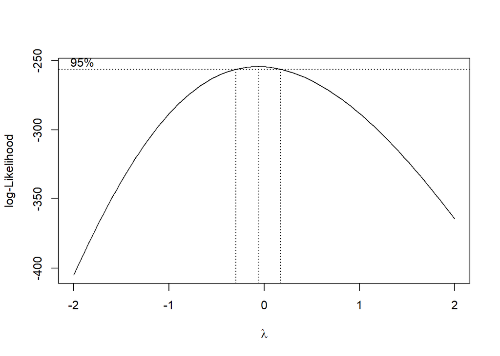

```r
index <- seq(1:120)
bc = boxcox(mpdw.train~index, lambda = seq(-2,2,by=0.1))
```

```r
#Nilai Rounded Lambda
lambda <- bc$x[which.max(bc$y)]
lambda
```

```
## [1] -0.06060606
```

```r
#SK
bc$x[bc$y > max(bc$y) - 1/2 * qchisq(.95,1)]
```

```
##  [1] -0.26262626 -0.22222222 -0.18181818 -0.14141414 -0.10101010 -0.06060606
##  [7] -0.02020202  0.02020202  0.06060606  0.10101010  0.14141414
```

Berdasarkan plot box-cox, nilai lamda berkisar -0.26 hingga 0.1414 atau dengan kata lain tidak mencangkup nilai 1 sehingga data tidak stasioner dalam ragam. Adapun nilai lamda optimumnya sebesar -0.0606

```r
#Transformasi
```

## Spesifikasi Model

```
## AR/MA
##   0 1 2 3 4 5 6 7 8 9 10 11 12 13
## 0 o x o o o o o o o o o  o  o  o
## 1 x x o o o o o o o o o  o  o  o
## 2 x o o o o o o o o o o  o  o  o
## 3 x o x o o o o o o o o  o  o  o
## 4 x x o o o o o o o o o  o  o  o
## 5 x x o o o o o o o o o  o  o  o
## 6 x x o o o o o o o o o  o  o  o
## 7 o x x o o o o o o o o  o  o  o
```

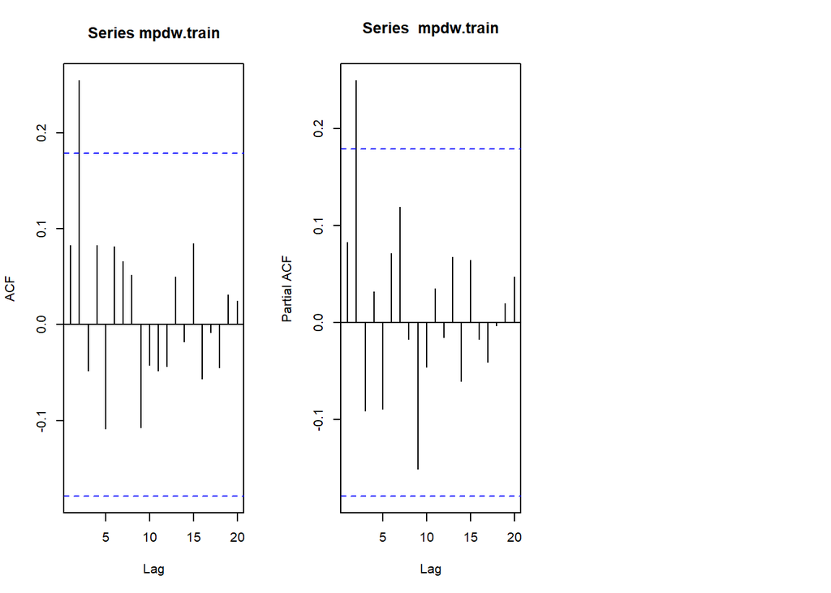

```r
par(mfrow=c(1,3))
#Plot ACF
acf(mpdw.train,lag.max = 20)

#Plot PACF
pacf(mpdw.train,lag.max = 20)

#Plot EACF
eacf(mpdw.train)
```

Berdasarkan gambar ACF dan PACF, diketahui bahwa pada lag 2 data terjadi cut-off sehingga dapat diduga modelnya mengikuti ARIMA (0,0,2) dan ARIMA (2,0,0). Selain itu pada plot EACF, terdapat dugaan model lain dengan melihat ujung segitiga berlambang ‘o’, yaitu ARIMA (1,0,2) dan ARIMA (2,0,2)

## Pendugaan Parameter

Dari 4 model tentatif yang didapat, akan dipilih yang terbaik berdasarkan AIC model dan signifikansi parameternya

```r
#ARIMA (0,0,2)
model1=Arima(mpdw.train, order=c(0,0,2),method="ML")
summary(model1)
```

```
## Series: mpdw.train
## ARIMA(0,0,2) with non-zero mean
##
## Coefficients:
##          ma1     ma2       mean
##       0.0707  0.2378  3972.9843
## s.e.  0.0907  0.0828   348.0214
##
## sigma^2 = 8764424:  log likelihood = -1127.99
## AIC=2263.97   AICc=2264.32   BIC=2275.12
##
## Training set error measures:
##                    ME     RMSE      MAE       MPE     MAPE      MASE       ACF1
## Training set 3.019408 2923.237 2412.724 -71.57924 100.6521 0.8739541 0.00402601
```

```r
lmtest::coeftest(model1)
```

```
##
## z test of coefficients:
##
##             Estimate Std. Error z value  Pr(>|z|)
## ma1       7.0749e-02 9.0701e-02  0.7800  0.435376
## ma2       2.3782e-01 8.2774e-02  2.8731  0.004064 **
## intercept 3.9730e+03 3.4802e+02 11.4159 < 2.2e-16 ***
## ---
## Signif. codes:  0 '***' 0.001 '**' 0.01 '*' 0.05 '.' 0.1 ' ' 1
```

```r
#ARIMA (2,0,0)
model2=Arima(mpdw.train, order=c(2,0,0),method="ML")
summary(model2)
```

```
## Series: mpdw.train
## ARIMA(2,0,0) with non-zero mean
##
## Coefficients:
##          ar1     ar2       mean
##       0.0631  0.2527  3975.5355
## s.e.  0.0879  0.0887   386.6502
##
## sigma^2 = 8731341:  log likelihood = -1127.77
## AIC=2263.54   AICc=2263.89   BIC=2274.69
##
## Training set error measures:
##                    ME     RMSE      MAE       MPE     MAPE      MASE       ACF1
## Training set 8.344653 2917.714 2400.516 -70.81098 99.90196 0.8695321 0.02072082
```

```r
lmtest::coeftest(model2)
```

```
##
## z test of coefficients:
##
##             Estimate Std. Error z value  Pr(>|z|)
## ar1       6.3108e-02 8.7854e-02  0.7183  0.472557
## ar2       2.5270e-01 8.8671e-02  2.8498  0.004374 **
## intercept 3.9755e+03 3.8665e+02 10.2820 < 2.2e-16 ***
## ---
## Signif. codes:  0 '***' 0.001 '**' 0.01 '*' 0.05 '.' 0.1 ' ' 1
```

```r
#ARIMA (1,0,2)
model3=Arima(mpdw.train, order=c(1,0,2),method="ML")
summary(model3)
```

```
## Series: mpdw.train
## ARIMA(1,0,2) with non-zero mean
##
## Coefficients:
##          ar1      ma1     ma2       mean
##       0.1219  -0.0485  0.2416  3975.6355
## s.e.  0.3744   0.3687  0.0886   361.0866
##
## sigma^2 = 8833876:  log likelihood = -1127.95
## AIC=2265.9   AICc=2266.43   BIC=2279.84
##
## Training set error measures:
##                    ME     RMSE      MAE       MPE     MAPE      MASE
## Training set 3.637045 2922.227 2402.273 -71.44702 100.4234 0.8701686
##                      ACF1
## Training set -0.000625095
```

```r
lmtest::coeftest(model3)
```

```
##
## z test of coefficients:
##
##              Estimate  Std. Error z value  Pr(>|z|)
## ar1          0.121943    0.374431  0.3257  0.744669
## ma1         -0.048487    0.368651 -0.1315  0.895360
## ma2          0.241633    0.088597  2.7273  0.006385 **
## intercept 3975.635489  361.086612 11.0102 < 2.2e-16 ***
## ---
## Signif. codes:  0 '***' 0.001 '**' 0.01 '*' 0.05 '.' 0.1 ' ' 1
```

```r
#ARIMA (2,0,2)
model4=Arima(mpdw.train, order=c(2,0,2),method="ML")
summary(model4)
```

```
## Series: mpdw.train
## ARIMA(2,0,2) with non-zero mean
##
## Coefficients:
##           ar1     ar2     ma1      ma2       mean
##       -0.2988  0.3697  0.3923  -0.0995  3968.0242
## s.e.   0.2913  0.2589  0.3104   0.2703   366.5665
##
## sigma^2 = 8776955:  log likelihood = -1127.07
## AIC=2266.13   AICc=2266.88   BIC=2282.86
##
## Training set error measures:
##                    ME     RMSE      MAE       MPE     MAPE      MASE
## Training set 7.186869 2900.215 2386.729 -69.66068 98.62552 0.8645381
##                       ACF1
## Training set -0.0007981108
```

```r
lmtest::coeftest(model4)
```

```
##
## z test of coefficients:
##
##              Estimate  Std. Error z value Pr(>|z|)
## ar1         -0.298786    0.291344 -1.0255   0.3051
## ar2          0.369734    0.258927  1.4279   0.1533
## ma1          0.392275    0.310374  1.2639   0.2063
## ma2         -0.099507    0.270338 -0.3681   0.7128
## intercept 3968.024167  366.566458 10.8248   <2e-16 ***
## ---
## Signif. codes:  0 '***' 0.001 '**' 0.01 '*' 0.05 '.' 0.1 ' ' 1
```

Berdasarkan uji signifikansi parameter, diketahui bahwa semua model mengandung parameter yang tidak signifikan. Adapun model dengan AIC terkecil pada ARIMA (2,0,0) sehingga dipilih model terbaiknya adalah ARIMA (2,0,0).

## Eksplorasi Sisaan

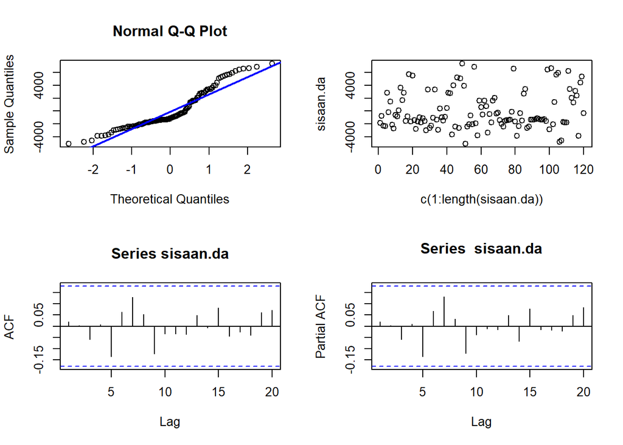

```r
#Eksplorasi
sisaan.da <- model2$residuals
par(mfrow=c(2,2))

#Q-Q plot
qqnorm(sisaan.da)
qqline(sisaan.da, col = "blue", lwd = 2)

#Plot Sisaan
plot(c(1:length(sisaan.da)),sisaan.da)

#Plot ACF
acf(sisaan.da)

#Plot PACF
pacf(sisaan.da)
```

```r
par(mfrow = c(1,1))
```

Berdasarkan plot kuantil-kuantil normal, secara eksplorasi ditunjukkan sisaan tidak menyebar normal ditandai dengan titik titik yang cenderung tidak mengikuti garis $45^{\circ}$. Kemudian dapat dilihat juga lebar pita sisaan yang cenderung tidak sama menandakan bahwa sisaan memiliki ragam yang heterogen. Plot ACF dan PACF sisaan ARIMA(2,0,0) juga tidak signifikan pada 20 lag awal yang menandakan saling bebas. Kondisi ini akan diuji lebih lanjut dengan uji formal.

## Uji Formal

1. Kenormalan sisaan

   ```r
   #1) Sisaan Menyebar Normal
   ks.test(sisaan.da,"pnorm")
   ```

   ```
   ##
   ##  One-sample Kolmogorov-Smirnov test
   ##
   ## data:  sisaan.da
   ## D = 0.65, p-value < 2.2e-16
   ## alternative hypothesis: two-sided
   ```

   Hipotesis pada uji KS adalah sebagai berikut.

   $H_0$ : Sisaan menyebar normal

   $H_1$ : Sisaan tidak menyebar normal

   Berdasarkan uji KS tersebut, didapat *p-value* sebesar < 2.2e-16 yang kurang dari taraf nyata 5% sehingga tolak $H_0$ dan menandakan bahwa sisaan tidak menyebar normal. Hal ini sesuai dengan hasil eksplorasi menggunakan plot kuantil-kuantil normal.
2. Autokorelasi sisaan

   ```r
   Box.test(sisaan.da, type = "Ljung")
   ```

   ```
   ##
   ##  Box-Ljung test
   ##
   ## data:  sisaan.da
   ## X-squared = 0.052821, df = 1, p-value = 0.8182
   ```

   Hipotesis yang digunakan adalah sebagai berikut.

   $H_0$ : Sisaan saling bebas

   $H_1$ : Sisaan tidak tidak saling bebas

   Berdasarkan uji Ljung-Box tersebut, didapat *p-value* sebesar 0.8182 yang lebih besar dari taraf nyata 5% sehingga tak tolak $H_0$ dan menandakan bahwa sisaan saling bebas.
3. Homogenitas sisaan

   ```r
   Box.test((sisaan.da)^2, type = "Ljung")
   ```

   ```
   ##
   ##  Box-Ljung test
   ##
   ## data:  (sisaan.da)^2
   ## X-squared = 2.3395, df = 1, p-value = 0.1261
   ```

   Hipotesis yang digunakan untuk uji kehomogenan ragam adalah sebagai berikut.

   $H_0$ : Ragam sisaan homogen

   $H_1$ : Ragam sisaan tidak homogen

   Berdasarkan uji Ljung-Box terhadap sisaan kuadrat tersebut, didapat *p-value* sebesar 0.1261 yang lebih dari taraf nyata 5% sehingga tak tolak $H_0$ dan menandakan bahwa ragam sisaan homogen. Hal ini berbeda dengan eksplorasi
4. Nilai harapan = 0

   ```r
   t.test(sisaan.da, mu = 0, conf.level = 0.95)
   ```

   ```
   ##
   ##  One Sample t-test
   ##
   ## data:  sisaan.da
   ## t = 0.031199, df = 119, p-value = 0.9752
   ## alternative hypothesis: true mean is not equal to 0
   ## 95 percent confidence interval:
   ##  -521.2635  537.9528
   ## sample estimates:
   ## mean of x
   ##  8.344653
   ```

   Hipotesis yang diujikan sebagai berikut :

   $H_0$ : nilai tengah sisaan sama dengan 0

   $H_1$ : nilai tengah sisaan tidak sama dengan 0

   Berdasarkan uji-ttersebut, didapat *p-value* sebesar 0.9752 yang lebih besar dari taraf nyata 5% sehingga tak tolak $H_0$ dan menandakan bahwa nilai tengah sisaan sama dengan nol.

## Uji Overfitting

Karena model terbaik sementara yang didapatkan adalah ARIMA (2,0,0), akan dilakukan tahapan uji overfitting terhadap model ARIMA (2,0,1) dan ARIMA (3,0,0)

```r
#ARIMA (2,0,0)
model2=Arima(mpdw.train, order=c(2,0,0),method="ML")
summary(model2)
```

```
## Series: mpdw.train
## ARIMA(2,0,0) with non-zero mean
##
## Coefficients:
##          ar1     ar2       mean
##       0.0631  0.2527  3975.5355
## s.e.  0.0879  0.0887   386.6502
##
## sigma^2 = 8731341:  log likelihood = -1127.77
## AIC=2263.54   AICc=2263.89   BIC=2274.69
##
## Training set error measures:
##                    ME     RMSE      MAE       MPE     MAPE      MASE       ACF1
## Training set 8.344653 2917.714 2400.516 -70.81098 99.90196 0.8695321 0.02072082
```

```r
lmtest::coeftest(model2)
```

```
##
## z test of coefficients:
##
##             Estimate Std. Error z value  Pr(>|z|)
## ar1       6.3108e-02 8.7854e-02  0.7183  0.472557
## ar2       2.5270e-01 8.8671e-02  2.8498  0.004374 **
## intercept 3.9755e+03 3.8665e+02 10.2820 < 2.2e-16 ***
## ---
## Signif. codes:  0 '***' 0.001 '**' 0.01 '*' 0.05 '.' 0.1 ' ' 1
```

```r
#ARIMA (2,0,1)
model1.ovt=Arima(mpdw.train, order=c(2,0,1),method="ML")
summary(model1.ovt)
```

```
## Series: mpdw.train
## ARIMA(2,0,1) with non-zero mean
##
## Coefficients:
##           ar1     ar2     ma1       mean
##       -0.3588  0.2765  0.4557  3966.6065
## s.e.   0.3010  0.0888  0.3143   354.8919
##
## sigma^2 = 8710996:  log likelihood = -1127.13
## AIC=2264.26   AICc=2264.79   BIC=2278.2
##
## Training set error measures:
##                    ME     RMSE      MAE       MPE     MAPE      MASE
## Training set 5.471904 2901.832 2386.634 -69.69261 98.57584 0.8645035
##                      ACF1
## Training set -0.004753801
```

```r
lmtest::coeftest(model1.ovt)
```

```
##
## z test of coefficients:
##
##              Estimate  Std. Error z value  Pr(>|z|)
## ar1         -0.358776    0.301026 -1.1918  0.233323
## ar2          0.276486    0.088779  3.1143  0.001844 **
## ma1          0.455668    0.314336  1.4496  0.147164
## intercept 3966.606481  354.891871 11.1769 < 2.2e-16 ***
## ---
## Signif. codes:  0 '***' 0.001 '**' 0.01 '*' 0.05 '.' 0.1 ' ' 1
```

```r
#ARIMA (3,0,0)
model2.ovt=Arima(mpdw.train, order=c(3,0,0),method="ML")
summary(model2.ovt)
```

```
## Series: mpdw.train
## ARIMA(3,0,0) with non-zero mean
##
## Coefficients:
##          ar1     ar2      ar3       mean
##       0.0840  0.2555  -0.0848  3969.5140
## s.e.  0.0904  0.0884   0.0923   354.8122
##
## sigma^2 = 8743643:  log likelihood = -1127.35
## AIC=2264.7   AICc=2265.22   BIC=2278.63
##
## Training set error measures:
##                    ME     RMSE      MAE       MPE     MAPE      MASE
## Training set 4.143896 2907.265 2389.835 -70.22607 99.11641 0.8656632
##                     ACF1
## Training set 0.002729886
```

```r
lmtest::coeftest(model2.ovt)
```

```
##
## z test of coefficients:
##
##              Estimate  Std. Error z value  Pr(>|z|)
## ar1          0.084011    0.090439  0.9289  0.352928
## ar2          0.255512    0.088396  2.8905  0.003846 **
## ar3         -0.084832    0.092257 -0.9195  0.357824
## intercept 3969.513969  354.812244 11.1876 < 2.2e-16 ***
## ---
## Signif. codes:  0 '***' 0.001 '**' 0.01 '*' 0.05 '.' 0.1 ' ' 1
```

Jika dibandingkan dengan ARIMA (2,0,1) dan ARIMA (3,0,0), model ARIMA (2,0,0) tetap memiliki nilai AIC yang terkecil sehingga dipilih model ARIMA (2,0,0) untuk forecasting

## Forecasting

Forecasting dilakukan dengan meramal data pada 30 periode kedepan dari data trainingnya

```r
ramalan <- forecast::forecast(model2, h = 30)
ramalan
```

```
##     Point Forecast      Lo 80    Hi 80     Lo 95     Hi 95
## 121       5317.894 1531.05724 9104.730  -473.573 11109.361
## 122       4381.290  586.92015 8175.660 -1421.698 10184.278
## 123       4340.350  423.46051 8257.240 -1650.016 10330.716
## 124       4101.091  182.30975 8019.872 -1892.168 10094.349
## 125       4075.646  148.68738 8002.605 -1930.119 10081.412
## 126       4013.581   86.34347 7940.818 -1992.610 10019.771
## 127       4003.234   75.42617 7931.042 -2003.830 10010.298
## 128       3986.897   59.05673 7914.738 -2020.216  9994.011
## 129       3983.252   55.37030 7911.133 -2023.925  9990.428
## 130       3978.894   51.00860 7906.779 -2028.288  9986.075
## 131       3977.697   49.80936 7905.585 -2029.489  9984.884
## 132       3976.521   48.63221 7904.409 -2030.666  9983.707
## 133       3976.144   48.25544 7904.033 -2031.043  9983.331
## 134       3975.823   47.93427 7903.711 -2031.364  9983.010
```

[output cut: 16 more lines]

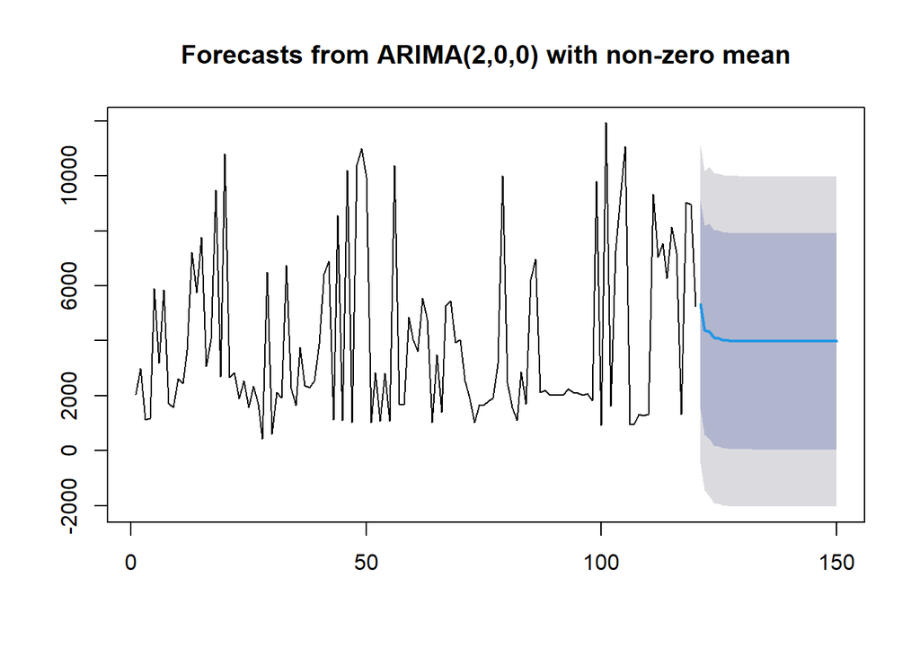

```r
data.ramalan.da <- ramalan$mean
plot(ramalan)
```

Berdasarkan forecasting, data ramalan cenderung menurun pada awal periode hingga akhirnya stabil di akhir periode

## Akurasi Ramalan

Akurasi ramalan tersebut dinilai berdasarkan perbandingan nilai ramalan terhadap data testing yang telah dibagi sebelumnya

```r
perbandingan<-matrix(data=c(mpdw6[121:150,1], data.ramalan.da),
                     nrow = 30, ncol = 2)
colnames(perbandingan)<-c("Aktual","Hasil Forecast")
perbandingan
```

```
##          Aktual Hasil Forecast
##  [1,]  6931.300       5317.894
##  [2,]  5624.100       4381.290
##  [3,]  9404.800       4340.350
##  [4,]  1103.330       4101.091
##  [5,]   625.630       4075.646
##  [6,]   956.460       4013.581
##  [7,] 10688.500       4003.234
##  [8,]  1880.000       3986.897
##  [9,] 11800.000       3983.252
## [10,]  5670.784       3978.894
## [11,] 11000.000       3977.697
## [12,] 11000.000       3976.521
## [13,]  8000.000       3976.144
## [14,]   800.000       3975.823
```

[output cut: 16 more lines]

```r
accuracy(data.ramalan.da,mpdw6[121:150,1])
```

```
##                ME     RMSE      MAE       MPE     MAPE
## Test set 1173.916 4128.341 3545.002 -114.4746 164.9973
```

```r
#Note : mpdw6[121:150,1] merupakan data testing
```

Nilai akurasi forecasting diukur berdasarkan nilai MAPE dan RMSE. Adapun nilai MAPE yang didapatkan sebesar 164.9973 dan RMSE sebesar 4128.341